# Localisation using Wifi fingerprints

Elena Bonan

In this script you can find the code we used to create the models after we have studied in details the dataset.

## R Markdown setting and R packages

```r
knitr::opts_chunk$set(warnings = FALSE)

if(require("pacman")=="FALSE"){
  install.packages("pacman")
}
pacman::p_load(rstudioapi,kknn,ggplot2, randomForest, dplyr, shiny, tidyr, ggplot2, caret, gridExtra)
```

# Preprocessing

In this first part of the code we clean the data in order to fit the model just with right and useful information.

## Dataset

We load the data and save the path to the folder where we are going to save the models.

```r
df = read.csv(file = 'trainingData.csv', header = TRUE, sep = ',')
validation = read.csv(file = 'validationData.csv', header = TRUE)
model_paths = './Models'
head(df)
```

|  | WAP001 | WAP002 | WAP003 | WAP004 | WAP005 | WAP006 | WAP007 | WAP008 | WAP009 | WAP010 | WAP011 | WAP012 | WAP013 | WAP014 | WAP015 | WAP016 | WAP017 | WAP018 | WAP019 | WAP020 | WAP021 | WAP022 | WAP023 | WAP024 | WAP025 | WAP026 | WAP027 | WAP028 | WAP029 | … |
| --- | --- | --- | --- | --- | --- | --- | --- | --- | --- | --- | --- | --- | --- | --- | --- | --- | --- | --- | --- | --- | --- | --- | --- | --- | --- | --- | --- | --- | --- | --- |
| 1 | 100 | 100 | 100 | 100 | 100 | 100 | 100 | 100 | 100 | 100 | 100 | 100 | 100 | 100 | 100 | 100 | 100 | 100 | 100 | 100 | 100 | 100 | 100 | 100 | 100 | 100 | 100 | 100 | 100 | … |
| 2 | 100 | 100 | 100 | 100 | 100 | 100 | 100 | 100 | 100 | 100 | 100 | 100 | 100 | 100 | 100 | 100 | 100 | 100 | 100 | 100 | 100 | 100 | 100 | 100 | 100 | 100 | 100 | 100 | 100 | … |
| 3 | 100 | 100 | 100 | 100 | 100 | 100 | 100 | -97 | 100 | 100 | 100 | 100 | 100 | 100 | 100 | 100 | 100 | 100 | 100 | 100 | 100 | 100 | 100 | 100 | 100 | 100 | 100 | 100 | 100 | … |
| 4 | 100 | 100 | 100 | 100 | 100 | 100 | 100 | 100 | 100 | 100 | 100 | 100 | 100 | 100 | 100 | 100 | 100 | 100 | 100 | 100 | 100 | 100 | 100 | 100 | 100 | 100 | 100 | 100 | 100 | … |
| 5 | 100 | 100 | 100 | 100 | 100 | 100 | 100 | 100 | 100 | 100 | 100 | 100 | 100 | 100 | 100 | 100 | 100 | 100 | 100 | 100 | 100 | 100 | 100 | 100 | 100 | 100 | 100 | 100 | 100 | … |
| 6 | 100 | 100 | 100 | 100 | 100 | 100 | 100 | 100 | 100 | 100 | 100 | 100 | 100 | 100 | 100 | 100 | 100 | 100 | 100 | 100 | 100 | 100 | 100 | 100 | 100 | 100 | 100 | 100 | 100 | … |

## Data Cleaning

We put the variable in the right type.

```r
df$PHONEID = as.factor(df$PHONEID)# we have 16: 1 10 11 13 14 16 17 18 19 22 23 24 3 6 7 8
df$USERID = as.factor(df$USERID)#From 1 to 18
df$FLOOR = as.factor(df$FLOOR)
df$BUILDINGID = as.factor(df$BUILDINGID)
df$SPACEID = as.factor(df$SPACEID)
df$RELATIVEPOSITION = as.factor(df$RELATIVEPOSITION)
validation$BUILDINGID = as.factor(validation$BUILDINGID)
validation$FLOOR = as.factor(validation$FLOOR)
```

We eliminate the variables that have zero variance since they can not be useful for the localization. Furthermore we eliminate the observations where there is no signal since they contained no information (they are not “linked” to a specific place in the building).

```r
# Eliminate the variables with zero variance
Var0_training= list()
for (i in 1:520){
  if (length(unique(df[,i])) == 1){
    Var0_training = append(Var0_training,i)
  }}

Var0_testing = list()
for (i in 1:520){
  if (length(unique(validation[,i])) == 1){
    Var0_testing = append(Var0_testing,i)}}

Var0 = append(Var0_training,Var0_testing)
mydf = df[,-unlist(Var0)]

# ELiminate the rows with no signals.
line = which( apply(df[,1:520],1,function(x){ length(unique(x))})== 1)
mydf = mydf[-line,]

# Eliminate the duplicates
mydf = unique(mydf)
```

We replace the value of no signal (100) with -105. Indeed, it is more useful for the models that this values is similar to the weaker RSSI level.

```r
# Replace no signal with the value -105.

for (i in 1:312){
  mydf[,i] = replace(mydf[,i],mydf[,i]==100,-105)
}

for (i in 1:520){
  validation[,i] = replace(validation[,i],validation[,i]==100,-105)
}
```

## Localize the WAPS

We want to find in which build is located every WAPS. Indeed, this information will be useful when build a model for every building. To locate a WAPS we look in which building the signal was received.

```r
# First divide the observations in the training according to the building in which it was take.
building0 = subset(mydf, mydf$BUILDINGID ==0)
building1 = subset(mydf, mydf$BUILDINGID == 1)
building2 = subset(mydf, mydf$BUILDINGID == 2)

#For every WAPS then we look if it signal was received in the different building.
index0 = which(apply(building0[,1:312], 2, function(x){length(unique(x))}) != 1)
# length(index0): 146
index1 = which(apply(building1[,1:312], 2, function(x){length(unique(x))}) != 1)
# length(index1): 168
index2 = which(apply(building2[,1:312], 2, function(x){length(unique(x))}) != 1)
# length(index2):122

# We look at the WAPS whose signal was received in more then one building
Waps_in_common = unique(c(intersect(index0, index1),intersect(index1, index2),intersect(index0, index2)))

# We look at the Waps whose signal is received in every building. The signal is  very low in all the buildings so we can not consider them.
intersect_all =  intersect(intersect(index0, index1),index2)#193,285

# We look at Waps whose signal is received in resp. building 0,1,2.
# For this WAPS we can already determined their position.
only0 = setdiff( index0, Waps_in_common)
only1 = setdiff( index1, Waps_in_common)
only2 = setdiff( index2, Waps_in_common)

# For the other I look in wwhich build was received the strongest signal.

l0 = c() # Waps that are in building 0
l1 = c()  # Waps that are in building 1
l2 = c()   # Waps that are in building 2

for (i in intersect(index0,index1)){
  if (i != 193 & i != 285){

    value0 = building0[i][building0[i] != -105 ]
    value1 = building1[i][building1[i] != -105 ]
    if ( abs(max(value0)-max(value1))>5 ){
      if(max(value0)> max(value1) & length(value0)> length(value1)){
        l0=c(l0,i)
      }
      if (length(value1)> length(value0)){l1 = c(l1,i)}
    }
  }}

for (i in intersect(index0,index2)){
  if (i != 193 & i != 285){

    value0 = building0[i][building0[i] != -105 ]
    value2 = building2[i][building2[i] != -105 ]
    if ( abs(max(value0)-max(value2))>5 ){
      if(max(value0)> max(value2) & length(value0)> length(value2)){
        l0=c(l0,i)
      }
      if (length(value2)> length(value0)){l2 = c(l2,i)}
    }
  }}

for (i in intersect(index1,index2)){
  if (i != 193 & i != 285){
    value1 = building1[i][building1[i] != -105 ]
    value2 = building2[i][building2[i] != -105 ]
    if ( abs(max(value1)-max(value2))>5 ){
      if(max(value1)> max(value2) & length(value1)> length(value2)){
        l1=c(l1,i)
      }
      if (length(value2)> length(value1)){l2 = c(l2,i)}
    }
  }}

final0 = c(only0, l0)
final1 = c(only1, l1)
final2 = c(only2, l2)
finalcol = c(final0,final1,final2)
```

# Modeling

There are different appraches possible to construct a model for determing the position of a person. After have carefully considered all the possibilities, we decide to do the following:

1. Predict the building using all the training.
2. Build a model for every building using as traing the observations taken in that building and the WAPS we have located there.

## Training set

We consider just the WAPS that we have located in one of the three building. We prepare the folders for the cross validation.

```r
fitControl <- trainControl(
  method = "repeatedcv",
  number = 10,
  repeats = 1)

mydf1 = mydf[,c(finalcol,313:321)]
```

## Model to identify the building

Prepare the data set with just the useful columns we are going to use.

```r
building = mydf1[,c(1:length(finalcol))]
building$BUILDINGID = mydf$BUILDINGID
```

We try three well known models (KNN, random forest and SVM) with different parameters.

```r
# List to save the results of the models
validation_building= list()
models_building = list()

#KNN
set.seed(123)
mod_knn <- train(BUILDINGID~., data = building, method = "knn",tuneGrid= expand.grid(k = c(1)), trControl=fitControl)


#Random Forest
set.seed(123)
mod_forest <- randomForest(BUILDINGID~., data = building, ntree= 100)

#Support Vector Machine
set.seed(123)
mod_svm <-  svm( BUILDINGID ~., data = building, trControl=fitControl, metric=accuracy)

# Save the performance
models_building = list( mod_knn, mod_forest, mod_svm)
 for (i in models_building){
   prediction = predict(i,validation)
   performance <- confusionMatrix(prediction, validation$BUILDINGID)
   validation_building = append(validation_building, performance)}
```

After have looked at the confusion metrix of the different models, we decide that the best model is knn with k = 1. In the following table you can see the confusion matrix of this model.

```r
model_building <- readRDS(paste(model_paths,"/model_building",sep =''))
prediction = predict(model_building,validation)
performance <- confusionMatrix(prediction, validation$BUILDINGID)
table(prediction, validation$BUILDINGID)
```

[output not shown]

We have just two positions of the validation set that were not located in the correct building. We plot their real positions to check if we can understand why this has happened. We think that the uncorrect classification in building 2 can be due to the fact that there were no positions in the training in that zone.

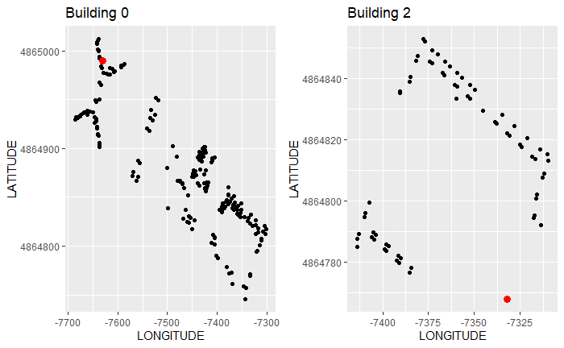

```r
# Position in the building 0, floor 0
plot1 = ggplot( subset(mydf,FLOOR == 0), aes(x = LONGITUDE, y = LATITUDE)) +
   geom_point() +
   geom_point(aes(x =  -7630.856, y= 4864990), colour="red" , size = 3)+ggtitle("Building 0")

# Position in the building 2, floor 4
plot2 = ggplot( subset(mydf,FLOOR == 4), aes(x = LONGITUDE, y = LATITUDE)) +
geom_point() +geom_point(aes(x =  -7331.9, y= 4864768 ), colour="red" , size = 3)+ggtitle("Building 2")

grid.arrange(plot1, plot2, ncol=2)
```

From now on we will not consider these two observation of the validation. We prepare the new validation data where we have removed these two observations.

```r
validation1=validation[-c(488,926),]
```

## Model for the buildings

For the three buildings we have used the same steps in order to predict the position. The step are the followings:

- prepare the training with just the observations that were taken in that building and the signals of the WAPS that are in that building (We have found them in the preprocessing).
- predict the floor trying knn, random forest and svm with different parameters.
- predict the longitude trying knn, random forest and svm with different parameters.
- predict the latitude trying knn, random forest and svm with different parameters.
- Finally, we have put all the three information together and we have studied the distribution of the errors, in order to understang better the factors that influeced them (see also the word document to have more observations about the errors).

## Model for building 1

### Floor

We start predicting the floor.

```r
# list to save the results
floor = list()
performance = list()

# prepare the training and validation
i = 0
  columns = (get(paste("final", i, sep="")))
  building = mydf[,c(columns,315,316)]
  building = subset(building, BUILDINGID == i )
  building$BUILDINGID <-NULL
  building$FLOOR <- factor(building$FLOOR)
  validation2 = subset(validation1, BUILDINGID == i )
  validation2$FLOOR = factor(validation2$FLOOR)

# Knn
set.seed(123)
mod_knn <- train.kknn( FLOOR  ~., data = building, ks = c(1,2,3,4,5),kernels= c('triangular','optimal', "triweight"))

# Random forest
  set.seed(123)
  mod_forest <- randomForest(FLOOR~., data = building, ntree= 100)

# SVM
set.seed(123)
mod_svm <-  svm( FLOOR ~., data = building, trControl=fitControl, metric=accuracy)

# Save the performance
floor[[i+1]] = list( mod_knn, mod_forest, mod_svm)
result=list()
  for (j in floor[[i+1]]){
    prediction = predict(j,validation2)
    per <- confusionMatrix(prediction, factor(validation2$FLOOR))
    result = append( result, per)
  }
  performance[[i+1]]= result
```

After have analysed the three models, we saw the best results with the random forest. We find quite good results with an accuracy of 98%. Just one time we predicted a floor that was two levels more then the actual one, as you can see in the confusion matrix.

```r
B0_floor_model = readRDS(paste(model_paths,"/B0_floor_model ",sep =''))
B0_floor_prediction =readRDS(paste(model_paths,"/B0_floor_prediction  ", sep =''))
B0_floor_confusion =readRDS(paste(model_paths,"/B0_floor_confusion", sep =''))
print(B0_floor_confusion)
```

```
Confusion Matrix and Statistics

          Reference
Prediction   0   1   2   3
         0  74   2   0   0
         1   2 206   3   0
         2   1   0 161   2
         3   0   0   1  83

Overall Statistics

               Accuracy : 0.9794
                 95% CI : (0.9635, 0.9897)
    No Information Rate : 0.3888
    P-Value [Acc > NIR] : < 2.2e-16

                  Kappa : 0.9709

 Mcnemar's Test P-Value : NA

Statistics by Class:

                     Class: 0 Class: 1 Class: 2 Class: 3
Sensitivity            0.9610   0.9904   0.9758   0.9765
Specificity            0.9956   0.9847   0.9919   0.9978
Pos Pred Value         0.9737   0.9763   0.9817   0.9881
Neg Pred Value         0.9935   0.9938   0.9892   0.9956
Prevalence             0.1439   0.3888   0.3084   0.1589
Detection Rate         0.1383   0.3850   0.3009   0.1551
Detection Prevalence   0.1421   0.3944   0.3065   0.1570
Balanced Accuracy      0.9783   0.9875   0.9838   0.9871
```

### Longitude

We then predict the longitude.

```r
# Lists to save the results
longitude = list()
longitude_performance = list()

# prepare the training and validation
i = 0
columns = (get(paste("final", i, sep="")))
building = mydf[,c(columns,313,316)]
building = subset(building, BUILDINGID == i )
building$BUILDINGID <-NULL
validation2 = subset(validation1, BUILDINGID == i )

# KNN
set.seed(123)
mod_knn <- train.kknn( LONGITUDE ~., data = building, ks = c(1,2,3,4,5),kernels= c('triangular','optimal', "triweight","cos", "inv", "gaussian"))
  mod_knn <- train(LONGITUDE~., data = building, method = "knn", tuneGrid= expand.grid(k = c(4)))

# Random forest
set.seed(123)
mod_forest <- randomForest(LONGITUDE~., data = building, ntree= 100)

# SVM
set.seed(123)
mod_svm <-  svm(LONGITUDE~., data = building, trControl=fitControl, metric=accuracy)

# Save the performance
longitude[[i+1]]= list( mod_knn, mod_forest, mod_svm)
result = list()
for (j in longitude[[i+1]]){
    prediction = predict(j,validation2)
    per <- postResample(prediction, validation2$LONGITUDE)
    result = append( result, per)
  }
longitude_performance[[i+1]]= result
```

We obtain the best results with knn k = 4.

```r
B0_longitude_model = readRDS(paste(model_paths,"/B0_longitude_model",sep =''))
B0_longitude_prediction = readRDS(paste(model_paths,"/B0_longitude_prediction", sep =''))
B0_longitude_postresample = readRDS(paste(model_paths,"/B0_longitude_postresample ", sep =''))
B0_longitude_real = validation2$LONGITUDE
print(B0_longitude_postresample)
```

```
     RMSE  Rsquared       MAE
5.6756795 0.9549145 3.5460803
```

We plot the distribution of the errors in the test. Even if the errors greater then 20 are more often with the negative sign, we are quite satisfied with the distribution. The maximum error in module is 33 meters.

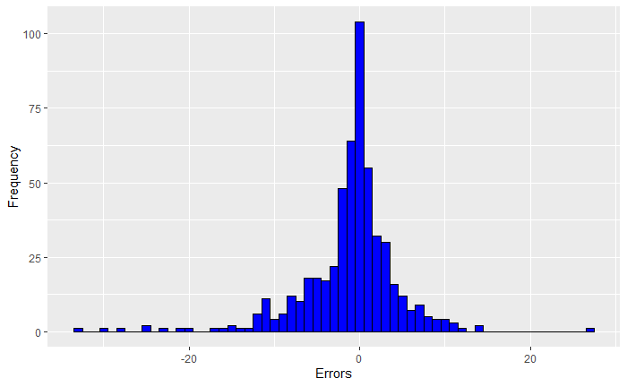

```r
 ggplot() + aes(B0_longitude_real - B0_longitude_prediction)+ geom_histogram(binwidth=1, colour="black", fill="blue")+xlab("Errors") + ylab('Frequency')
```

### Latitude

Finally we predict the latitude.

```r
# lists to save the results
latitude = list()
latitude_performance = list()

# prepare training and validation
i = 0
columns = (get(paste("final", i, sep="")))
building = mydf[,c(columns,314,316)]
building = subset(building, BUILDINGID == i )
building$BUILDINGID <-NULL
validation2 = subset(validation1, BUILDINGID == i )

#Knn
set.seed(123)
mod_knn <- train(LATITUDE~., data = building, method = "knn", trControl=fitControl,tuneGrid= expand.grid(k = c(4)))

# Random forest
set.seed(123)
mod_forest <- randomForest(LATITUDE~., data = building, ntree= 100)

#SVM
set.seed(123)
mod_svm <-  svm(LATITUDE~., data = building, trControl=fitControl, metric=accuracy)

# Save the results
latitude[[i+1]] = list( mod_knn, mod_svm, mod_forest)
result = list()
  for (j in latitude[[i+1]]){
    prediction = predict(j,validation2)
    per <- postResample(prediction, validation2$LATITUDE)
    result = append( result, per)
  }
  latitude_performance[[i+1]]= result
```

Also in this case, we find that the best result with knn, k = 4.

```r
B0_latitude_model =  readRDS(paste(model_paths,"/B0_latitude_model =  mod_knn", sep =''))
B0_latitude_prediction =  readRDS(paste(model_paths,"/B0_latitude_prediction", sep =''))
B0_latitude_postresample = postResample(B0_latitude_prediction , validation2$LATITUDE)
B0_latitude_real = validation2$LATITUDE
print(B0_latitude_postresample)
```

```
     RMSE  Rsquared       MAE
4.9303993 0.9762715 3.2243490
```

We plot the residuals to look at the distribution.

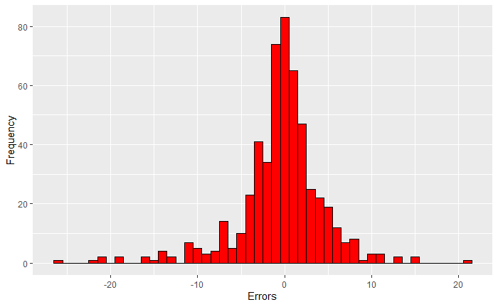

```r
ggplot() + aes(B0_latitude_real - B0_latitude_prediction)+ geom_histogram(binwidth=1, colour="black", fill="red")+xlab("Errors") + ylab('Frequency')
```

### Study of the errors

We can now put together all the three predictions (floor, longitudine and latitude) and represent better the errors we got.

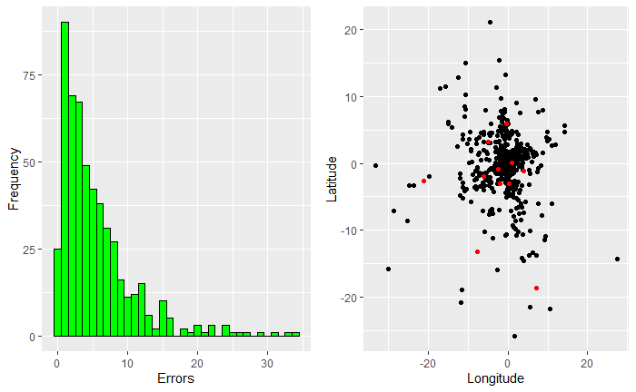

```r
# Distribution of the errors
error_distance = sqrt((B0_latitude_real - B0_latitude_prediction)^2+(B0_longitude_real - B0_longitude_prediction)^2)
plot1 = ggplot() + aes(error_distance)+ geom_histogram(binwidth=1, colour="black", fill="green")+xlab("Errors") + ylab('Frequency')

# Visualization of the errors in longitude, latitute and floor
E = validation2
E$long = B0_longitude_real - B0_longitude_prediction
E$lat = B0_latitude_real - B0_latitude_prediction

plot2 = ggplot()+ geom_point(data = E[which(B0_floor_prediction == factor(validation2$FLOOR)),], aes(x = long, y = lat))+xlab("Longitude") +
  geom_point(data = E[-which(B0_floor_prediction == factor(validation2$FLOOR)),], aes(x = long, y = lat),color='red')+xlab("Longitude") +
  ylab("Latitude")

grid.arrange(plot1, plot2, ncol=2)
```

Let us have a look at the positions of the errors in the following graph.

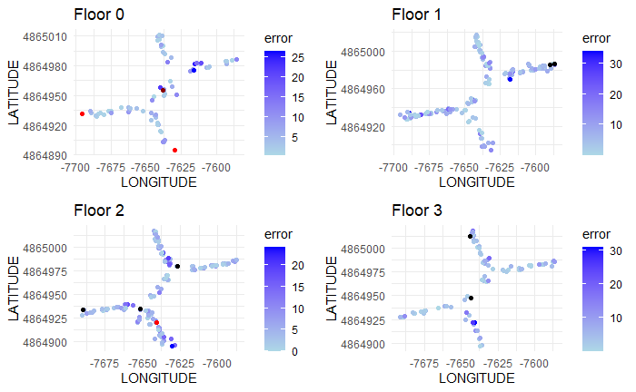

```r
# errors by floor
ERRORB0 = validation2
ERRORB0$error = error_distance
RIGHTFLOOR = ERRORB0[which(B0_floor_prediction == factor(validation2$FLOOR)),]
WRONGFLOORP1 = ERRORB0[which(as.integer(B0_floor_prediction) == (as.integer(validation2$FLOOR)+1)),]
WRONGFLOORP2 = ERRORB0[which(as.integer(B0_floor_prediction) == (as.integer(validation2$FLOOR)+2)),]
WRONGFLOORM1 = ERRORB0[which(as.integer(B0_floor_prediction) == (as.integer(validation2$FLOOR)-1)),]

# Plots of the errors
plots = list()
for (i in c(0,1:3)){
  g = ggplot() +  geom_point(data=subset(RIGHTFLOOR, FLOOR == i), aes(x=LONGITUDE, y =LATITUDE,color= error)) + scale_color_gradient(low = "lightblue", high = "blue")+
    geom_point(data= subset(WRONGFLOORP1,FLOOR==i), aes(x=LONGITUDE, y=LATITUDE), color='red')+
    geom_point(data= subset(WRONGFLOORP2,FLOOR==i), aes(x=LONGITUDE, y=LATITUDE), color='darkred')+
    geom_point(data= subset(WRONGFLOORM1,FLOOR==i), aes(x=LONGITUDE, y=LATITUDE), color='black')+
    ggtitle(paste('Floor',i))+theme_minimal()
plots[[i+1]]= g
}
grid.arrange(grobs=plots,ncol=2)
```

We see that for some observations in the extremities of the building, we have picked the wrong floor. One possible explanation is that we obtain some points in the floor above or below because we have less observations near the right position in the same floor.

## Model for building 2

We repeat the same steps of the previous building.

### Floor

We predict the floor.

```r
# List to save the results
floor = list()
performance = list()

# Training and validation
i = 1
columns = (get(paste("final", i, sep="")))
building = mydf[,c(columns,315,316, 319)]
building = subset(building, BUILDINGID == i)
building$BUILDINGID <-NULL
building$USERID <- NULL
building$FLOOR <- factor(building$FLOOR)
validation2 = subset(validation1, BUILDINGID == i )
validation2$FLOOR = factor(validation2$FLOOR)

#knn
set.seed(123)
mod_knn <- train.kknn( FLOOR  ~., data = building, ks = c(1,2,3,4,5),kernels= c('triangular','optimal', "triweight",'rectangular'))

#Random forest
set.seed(123)
mod_forest <- randomForest(FLOOR~., data = building, ntree= 100)

#SVM
set.seed(123)
mod_svm <-  svm( FLOOR ~., data = building, trControl=fitControl, metric=accuracy)

# Save the results
floor[[i+1]] = list( mod_knn ,mod_forest,mod_svm)
result=list()
for (j in floor[[i+1]]){
  prediction = predict(j,validation2)
  per <- confusionMatrix(prediction, factor(validation2$FLOOR))

  result = append( result, per)
}
```

```r
B1_floor_model = readRDS(paste(model_paths,"/B1_floor_model", sep =''))
B1_floor_prediction =readRDS(paste(model_paths,"/B1_floor_prediction", sep = ''))
B1_floor_confusion =readRDS(paste(model_paths,"/B1_floor_confusion", sep = ''))
B1_floor_confusion
```

```
Confusion Matrix and Statistics

          Reference
Prediction   0   1   2   3
         0  22   5   0   0
         1   5 109   1   2
         2   3  28  84   2
         3   0   1   2  43

Overall Statistics

               Accuracy : 0.8404
                 95% CI : (0.7945, 0.8795)
    No Information Rate : 0.4658
    P-Value [Acc > NIR] : < 2.2e-16

                  Kappa : 0.7663

 Mcnemar's Test P-Value : NA

Statistics by Class:

                     Class: 0 Class: 1 Class: 2 Class: 3
Sensitivity           0.73333   0.7622   0.9655   0.9149
Specificity           0.98195   0.9512   0.8500   0.9885
Pos Pred Value        0.81481   0.9316   0.7179   0.9348
Neg Pred Value        0.97143   0.8211   0.9842   0.9847
Prevalence            0.09772   0.4658   0.2834   0.1531
Detection Rate        0.07166   0.3550   0.2736   0.1401
Detection Prevalence  0.08795   0.3811   0.3811   0.1498
Balanced Accuracy     0.85764   0.8567   0.9078   0.9517
```

### Longitude

We predict the longitude.

```r
#Lists to save the results
longitude = list()
longitude_performance = list()

#Training and testing
i = 1
columns = (get(paste("final", i, sep="")))
building = mydf[,c(columns,313,316)]
building = subset(building, BUILDINGID == i )
building$BUILDINGID <-NULL
validation2 = subset(validation1, BUILDINGID == i )

#knn
set.seed(123)
mod_knn <- train.kknn( LONGITUDE ~., data = building, ks = c(1,2,3,4,5),kernels= c('triangular','optimal', "triweight","cos", "inv", "gaussian"))

#random forest
set.seed(123)
mod_forest <- randomForest(LONGITUDE~., data = building, ntree= 100)

#SVM
set.seed(123)
mod_svm <-  svm(LONGITUDE~., data = building, trControl=fitControl, metric=accuracy)

#Save the results
longitude[[i+1]] = list( mod_knn,mod_forest,mod_svm)
result = list()
for (j in longitude[[i+1]]){
  prediction = predict(j,validation2)
  per <- postResample(prediction, validation2$LONGITUDE)
  g = ggplot() + aes(validation2$LONGITUDE - prediction)+ geom_histogram(binwidth=1, colour="black", fill="blue")+xlab("Errors") + ylab('Frequency')
   result = append( result, per)
  }
  longitude_performance[[i+1]]= result
```

We chose the random forest.

```r
B1_longitude_model = readRDS(paste(model_paths,"/B1_longitude_model", sep =''))
B1_longitude_prediction = readRDS(paste(model_paths,"/B1_longitude_prediction", sep =''))
B1_longitude_postresample = readRDS(paste(model_paths,"/B1_longitude_postresample ", sep = ''))
print(B1_longitude_postresample)
```

```
     RMSE  Rsquared       MAE
9.0951672 0.9611917 6.5723053
```

We look at the distribution of the errors.

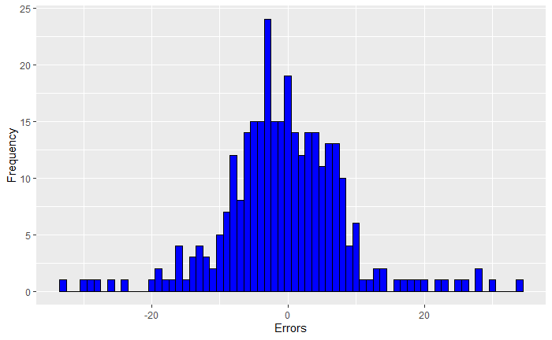

```r
ggplot() + aes(validation2$LONGITUDE - B1_longitude_prediction)+ geom_histogram(binwidth=1, colour="black", fill="blue")+xlab("Errors") + ylab('Frequency')
```

### Latitude

We predict the latitude.

```r
latitude = list()
latitude_performance = list()

i = 1
columns = (get(paste("final", i, sep="")))
building = mydf[,c(columns,314,316)]
building = subset(building, BUILDINGID == i )
building$BUILDINGID <-NULL
validation2 = subset(validation1, BUILDINGID == i )

#knn
set.seed(123)
mod_knn <- train.kknn( LATITUDE~., data = building, ks = c(1,2,3,4,5),kernels= c('triangular','optimal', "triweight",'rectangular'))

#Random forest
set.seed(123)
mod_forest <- randomForest(LATITUDE~., data = building, ntree= 100)

#SVM
set.seed(123)
mod_svm <-  svm(LATITUDE~., data = building, trControl=fitControl, metric=accuracy)

# Save the results
latitude[[i+1]] = list( mod_knn,mod_forest, mod_svm)
result = list()
for (j in latitude[[i+1]]){
    prediction = predict(j,validation2)
    g = ggplot() + aes(validation2$LATITUDE - prediction)+ geom_histogram(binwidth=1, colour="black", fill="red")+xlab("Errors") + ylab('Frequency')
    print(g)
    per <- postResample(prediction, validation2$LATITUDE)
    result = append( result, per)
  }
latitude_performance[[i+1]]= result
```

We obtain the best results with the random forest.

```r
B1_latitude_model =  readRDS(paste(model_paths,"/B1_latitude_model =  mod_knn", sep = ''))
B1_latitude_prediction =  readRDS(paste(model_paths,"/B1_latitude_prediction", sep = ''))
B1_latitude_postresample = postResample(B1_latitude_prediction , validation2$LATITUDE)
print(B1_latitude_postresample)
```

```
      RMSE   Rsquared        MAE
11.0653046  0.9020603  7.7159373
```

We plot the distribution of the errors.

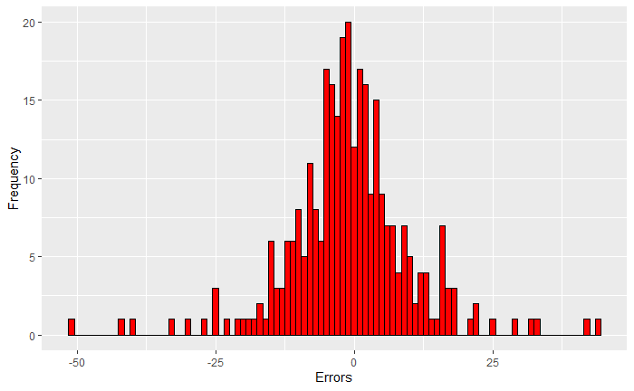

```r
ggplot() + aes(validation2$LATITUDE - B1_latitude_prediction)+ geom_histogram(binwidth=1, colour="black", fill="red")+xlab("Errors") + ylab('Frequency')
```

### Studying the errors

We look at the errors combinig all the predictions.

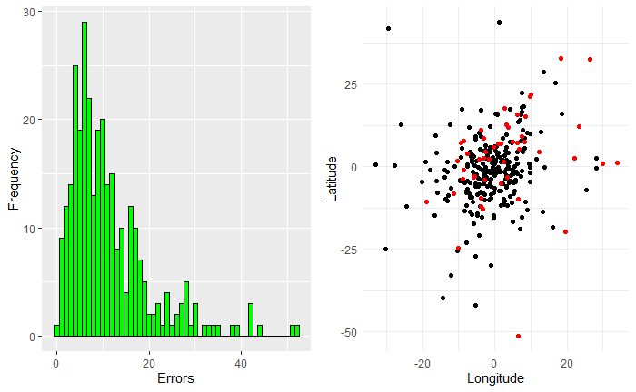

Position of the errors.

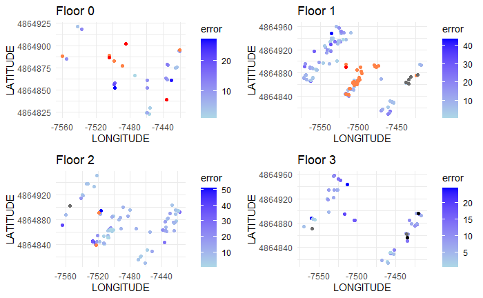

```r
# save the errors
ERRORB0 = validation2
ERRORB0$error = error_distance
RIGHTFLOOR = ERRORB0[which(B1_floor_prediction == factor(validation2$FLOOR)),]
WRONGFLOORP1 = ERRORB0[which(as.integer(B1_floor_prediction) == (as.integer(validation2$FLOOR)+1)),]
WRONGFLOORP2 = ERRORB0[which(as.integer(B1_floor_prediction) == (as.integer(validation2$FLOOR)+2)),]
WRONGFLOORP3 = ERRORB0[which(as.integer(B1_floor_prediction) == (as.integer(validation2$FLOOR)+3)),]
WRONGFLOORM1 = ERRORB0[which(as.integer(B1_floor_prediction) == (as.integer(validation2$FLOOR)-1)),]
WRONGFLOORM2 = ERRORB0[which(as.integer(B1_floor_prediction) == (as.integer(validation2$FLOOR)-2)),]
WRONGFLOORM3 = ERRORB0[which(as.integer(B1_floor_prediction) == (as.integer(validation2$FLOOR)-3)),]

# Graph
plots = list()
for (i in c(0,1:3)){
  g = ggplot() +  geom_point(data=subset(RIGHTFLOOR, FLOOR == i), aes(x=LONGITUDE, y =LATITUDE,color= error)) + scale_color_gradient(low = "lightblue", high = "blue")+
    geom_point(data= subset(WRONGFLOORP1,FLOOR==i), aes(x=LONGITUDE, y=LATITUDE), color='sienna1')+
    geom_point(data= subset(WRONGFLOORP2,FLOOR==i), aes(x=LONGITUDE, y=LATITUDE), color='red')+
    geom_point(data= subset(WRONGFLOORP3,FLOOR==i), aes(x=LONGITUDE, y=LATITUDE), color='darkred')+
    geom_point(data= subset(WRONGFLOORM1,FLOOR==i), aes(x=LONGITUDE, y=LATITUDE), color='gray42')+
    geom_point(data= subset(WRONGFLOORM2,FLOOR==i), aes(x=LONGITUDE, y=LATITUDE), color='black')+

    ggtitle(paste('Floor',i))+theme_minimal()
plots[[i+1]] = g
}
grid.arrange(grobs = plots, ncol= 2)
```

We have clearly a problem in the central region of the floor 1 since all the devices were located in the wrong floor.

## Model for building 3

We repeat the same steps done for the previous buildings.

### Floor

We predict the floor.

```r
# Lists to save the results
floor = list()
performance = list()

# We prepare the training and dataset
# We eliminate the observation of userid 6 which have a strange signal
i = 2
columns = (get(paste("final", i, sep="")))
building = mydf[,c(columns,315,316, 319)]
building = subset(building, BUILDINGID == i )
line = which(apply(building[,1:76],1, max)>-30)
line  = intersect(which(building$USERID == 6), line)
building = building[-line,]
building$BUILDINGID <-NULL
building$USERID <- NULL
building$FLOOR <- factor(building$FLOOR)
validation2 = subset(validation1, BUILDINGID == i )
validation2$FLOOR = factor(validation2$FLOOR)

#Knn
set.seed(123)
mod_knn <- train.kknn( FLOOR  ~., data = building, ks = c(1,2,3,4,5),kernels= c('triangular','optimal', "triweight",'rectangular'))

#Random forest
set.seed(123)
mod_forest <- randomForest(FLOOR~., data = building, ntree= 100)

#SVM
set.seed(123)
mod_svm <-  svm( FLOOR ~., data = building, trControl=fitControl, metric=accuracy)

# Save the results
floor[[i+1]] = list( mod_knn ,mod_forest,mod_svm)
result=list()
for (j in floor[[i+1]]){
  prediction = predict(j,validation2)
  per <- confusionMatrix(prediction, factor(validation2$FLOOR))

  result = append( result, per)
}
```

The best model is the random forest with 100 trees and mtry = 8.

```r
B2_floor_model = readRDS(paste(model_paths,"/B2_floor_model", sep = ''))
B2_floor_prediction =readRDS(paste(model_paths,"/B2_floor_prediction", sep = '' ))
B2_floor_confusion =readRDS(paste(model_paths,"/B2_floor_confusion", sep = ''))
print(B2_floor_confusion)
```

```
Confusion Matrix and Statistics

          Reference
Prediction   0   1   2   3   4
         0  21   0   0   0   0
         1   3 110   1   0   1
         2   0   1  51   0   0
         3   0   0   2  39   5
         4   0   0   0   1  32

Overall Statistics

               Accuracy : 0.9476
                 95% CI : (0.9136, 0.971)
    No Information Rate : 0.4157
    P-Value [Acc > NIR] : < 2.2e-16

                  Kappa : 0.9283

 Mcnemar's Test P-Value : NA

Statistics by Class:

                     Class: 0 Class: 1 Class: 2 Class: 3 Class: 4
Sensitivity           0.87500   0.9910   0.9444   0.9750   0.8421
Specificity           1.00000   0.9679   0.9953   0.9692   0.9956
Pos Pred Value        1.00000   0.9565   0.9808   0.8478   0.9697
Neg Pred Value        0.98780   0.9934   0.9860   0.9955   0.9744
Prevalence            0.08989   0.4157   0.2022   0.1498   0.1423
Detection Rate        0.07865   0.4120   0.1910   0.1461   0.1199
Detection Prevalence  0.07865   0.4307   0.1948   0.1723   0.1236
Balanced Accuracy     0.93750   0.9795   0.9699   0.9721   0.9189
```

### Longitude

We predict the longitude.

```r
# lists to save the results
longitude = list()
longitude_performance = list()

# Training and validation
i = 2
columns = (get(paste("final", i, sep="")))
building = mydf[,c(columns,313,316,319)]
building = subset(building, BUILDINGID == i)
line = which(apply(building[,1:76],1, max)>-30)
line  = intersect(which(building$USERID == 6), line)
building = building[-line,]
building$BUILDINGID <-NULL
building$USERID <- NULL
validation2 = subset(validation1, BUILDINGID == i )

# knn
set.seed(123)
mod_knn <- train.kknn( LONGITUDE~., data = building, ks = c(1,2,3,4,5),kernels= c('triangular','optimal', "triweight",'rectangular'))

# random forest
set.seed(123)
mod_forest <- randomForest(LONGITUDE~., data = building, ntree= 100)

# svm
set.seed(123)
mod_svm <-  svm(LONGITUDE~., data = building, trControl=fitControl, metric=accuracy)

# save the results
longitude[[i+1]] = list( mod_knn,mod_forest,mod_svm)
result = list()
for (j in longitude[[i+1]]){
  prediction = predict(j,validation2)
  per <- postResample(prediction, validation2$LONGITUDE)
  g = ggplot() + aes(validation2$LONGITUDE - prediction)+ geom_histogram(binwidth=1, colour="black", fill="blue")+xlab("Errors") + ylab('Frequency')
  print(g)
  result = append( result, per)
}
```

The best model is the random forest with mtry = 25.

```r
B2_longitude_model = readRDS(paste(model_paths,"/B2_longitude_model", sep = ''))
B2_longitude_prediction = readRDS(paste(model_paths,"/B2_longitude_prediction", sep = ''))
B2_longitude_postresample = readRDS(paste(model_paths,"/B2_longitude_postresample ", sep = ''))
print(B2_longitude_postresample)
```

```
      RMSE   Rsquared        MAE
10.2294082  0.8969764  6.8647263
```

We check the distribution of the errors.

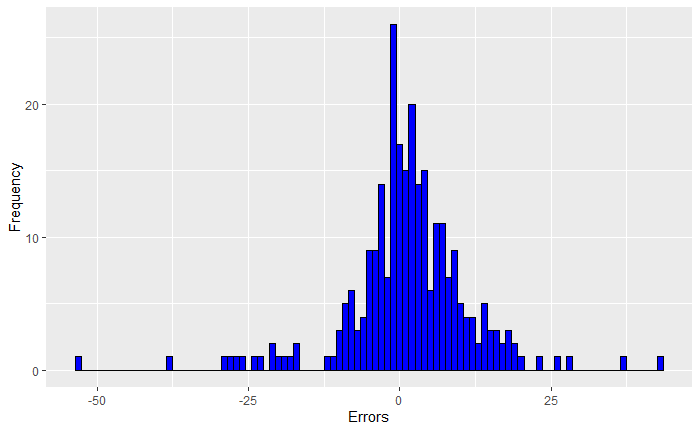

```r
ggplot() + aes(validation2$LONGITUDE - B2_longitude_prediction)+ geom_histogram(binwidth=1, colour="black", fill="blue")+xlab("Errors") + ylab('Frequency')
```

### Latitude

We predict the latitude.

```r
# Lists to save the results
latitude = list()
latitude_performance = list()

# training and validation
i = 2
columns = (get(paste("final", i, sep="")))
building = mydf[,c(columns,314,316,319)]
building = subset(building, BUILDINGID == i )
line = which(apply(building[,1:76],1, max)>-30)
line  = intersect(which(building$USERID == 6), line)
building = building[-line,]
building$BUILDINGID <-NULL
building$USERID <-NULL
validation2 = subset(validation1, BUILDINGID == i )

# Knn
set.seed(123)
mod_knn <- train.kknn( LATITUDE~., data = building, ks = c(1,2,3,4,5),kernels= c('triangular','optimal', "triweight",'rectangular'))

# random forest
set.seed(123)
mod_forest <- randomForest(LATITUDE~., data = building, ntree= 100)

#SVM
set.seed(123)
mod_svm <-  svm(LATITUDE~., data = building, trControl=fitControl, metric=accuracy)
latitude[[i+1]] = list( mod_knn,mod_forest, mod_svm)

# save the results
result = list()
for (j in latitude[[i+1]]){
  prediction = predict(j,validation2)
  g = ggplot() + aes(validation2$LATITUDE - prediction)+ geom_histogram(binwidth=1, colour="black", fill="red")+xlab("Errors") + ylab('Frequency')
  print(g)
  per <- postResample(prediction, validation2$LATITUDE)
  result = append( result, per)
}
latitude_performance[[i+1]]= result
```

The best model is knn with k = 5.

```r
B2_latitude_model =  readRDS(paste(model_paths,"/B2_latitude_model =  mod_knn", sep = ''))
B2_latitude_prediction =  readRDS(paste(model_paths,"/B2_latitude_prediction", sep = ''))
B2_latitude_postresample = readRDS(paste(model_paths,"/B2_latitude_postresample", sep = ''))
print(B2_latitude_postresample)
```

```
      RMSE   Rsquared        MAE
10.3578793  0.8752625  6.8412589
```

We look at the distribution of the errors.

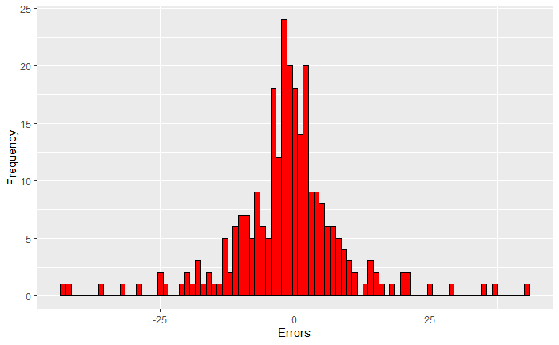

```r
ggplot() + aes(validation2$LATITUDE - B2_latitude_prediction)+ geom_histogram(binwidth=1, colour="black", fill="red")+xlab("Errors") + ylab('Frequency')
```

### Study of the errors

We study the errors comibining the three predictions.

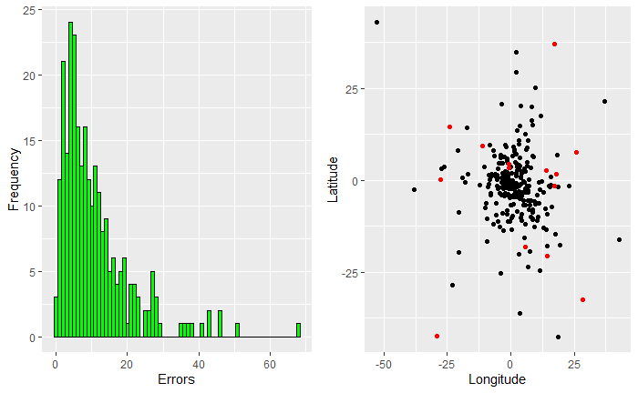

```r
# Distribution of the errors
error_distance = sqrt((validation2$LATITUDE - B2_latitude_prediction)^2+(validation2$LONGITUDE - B2_longitude_prediction)^2)
plot1 = ggplot() + aes(error_distance)+ geom_histogram(binwidth=1, colour="black", fill="green")+xlab("Errors") + ylab('Frequency')
#mean(error_distance)

# Visualization of the errors combined
E = validation2
E$long = validation2$LONGITUDE- B2_longitude_prediction
E$lat = validation2$LATITUDE - B2_latitude_prediction
plot2 = ggplot()+ geom_point(data = E[which(B2_floor_prediction == factor(validation2$FLOOR)),], aes(x = long, y = lat))+xlab("Longitude") +
  geom_point(data = E[-which(B2_floor_prediction == factor(validation2$FLOOR)),], aes(x = long, y = lat),color='red')+xlab("Longitude") +
  ylab("Latitude")
grid.arrange(plot1, plot2, ncol=2)
```

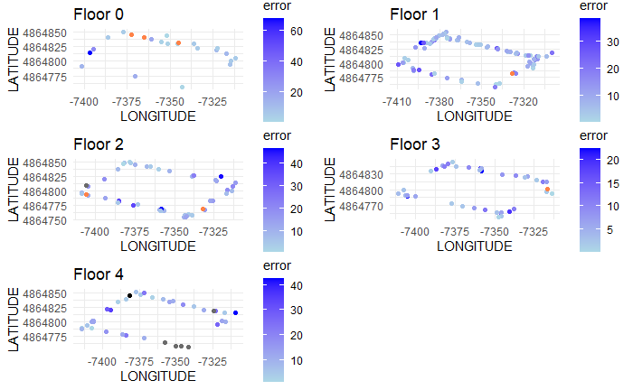

In the right-down-corner of the 4 floor we have that 4 observations were predicted in the third floor. The reason is that in that training there were no observation that zone. This tell us how important is to have observation in every zone. The particular shape of the building, hole in the middle, can also represent a problem: the signal of two places can be similar even if they are distant (since the waves propagate better without walls etc.).

## Conclusion

The model could be used in a real application to help people to find their position, if they are in the buildig 0. Indeed, given that we predicted the right floor (true in 98% of the cases), we obtained that in 90% of the observations in the validation the error was less then 12 meters. In the other two buildings the errors were too high for a concrete application.